# Cousera Practical Machine Learning: Assignment

Robin

April 2017

# Background

Using devices such as Jawbone Up, Nike FuelBand, and Fitbit it is now possible to collect a large amount of data about personal activity relatively inexpensively. These type of devices are part of the quantified self movement - a group of enthusiasts who take measurements about themselves regularly to improve their health, to find patterns in their behaviour, or because they are tech geeks. One thing that people regularly do is quantify how much of a particular activity they do, but they rarely quantify how well they do it.

## Project Goal

In this project, your goal will be to use data from accelerometers on the belt, forearm, arm, and dumbell of 6 participants. They were asked to perform barbell lifts correctly and incorrectly in 5 different ways. More information is available from the website here: http://groupware.les.inf.puc-rio.br/har (see the section on the Weight Lifting Exercise Dataset).

# Data

## Training Data set

The training data for this project are available here:

https://d396qusza40orc.cloudfront.net/predmachlearn/pml-training.csv

## Test Data Set

The test data are available here:

https://d396qusza40orc.cloudfront.net/predmachlearn/pml-testing.csv

We commence by downloading the required files and reading in the training and testing datasets, assigning missing values to entries that are currently ‘NA’ or blank.

## Get Data

```r
if(!file.exists("./data")){dir.create("./data")}
#Training File
if(!file.exists("./data/pml-training.csv")){fileUrlTr <- "https://d396qusza40orc.cloudfront.net/predmachlearn/pml-training.csv"
download.file(fileUrlTr,destfile="./data/pml-training.csv")}
# Testing File
if(!file.exists("./data/pml-testing.csv")){fileUrlTe <- "https://d396qusza40orc.cloudfront.net/predmachlearn/pml-testing.csv"
download.file(fileUrlTe,destfile="./data/pml-testing.csv")}
```

```r
df_training <- read.csv("./data/pml-training.csv", header = TRUE, na.strings = c("","NA"))
df_testing <- read.csv("./data/pml-testing.csv", header = TRUE, na.strings = c("","NA"))
# Remove the column names from the training and test set.
dataTidy <- df_training[,-c(grep("^amplitude|^kurtosis|^skewness|^avg|^cvtd_timestamp|^max|^min|^new_window|^raw_timestamp|^stddev|^var|^user_name|X",names(df_training)))]
dim(df_training)
```

```
## [1] 19622   160
```

```r
dim(df_testing)
```

```
## [1]  20 160
```

## Split the Training set into a Training and Validation set

```r
set.seed(333)
from_training <- createDataPartition(y = dataTidy$classe,p=0.6,list=FALSE)
train_set <- dataTidy[from_training,]
test_set <- dataTidy[-from_training,]
dim(train_set); dim(test_set)
```

```
## [1] 11776    54
```

```
## [1] 7846   54
```

## Model Comparison

1. The Random Forest (rf) and Boosting (gmb) algorithms were selected based on the accuracy these models can achieve.
2. The Kappa metric was selected as the comparison criteria.
3. To reduce overfitting, a 3-fold cross validation is employed during model construction.

### Boosting (gmb Model)

```r
set.seed(39)
# k-fold validation - 3-fold validation, use kappa as metric
fitControl <- trainControl(method = "cv", number = 3)
gbm_ModFit <- train(classe~., data = train_set, method = "gbm", metric = "Kappa", trControl = fitControl, verbose = FALSE)
```

### Random Forest (rf Model)

```r
rf_Modfit <- train(classe~.,data = train_set,method = "rf", metric = "Kappa", trControl = fitControl, verbose = FALSE)
```

## Model Selection

1. The two models are compared using the resamples function from the caret package

### Model Comparison

```r
rValues <- resamples(list(rf = rf_Modfit,gbm = gbm_ModFit))
summary(rValues)
```

```
##
## Call:
## summary.resamples(object = rValues)
##
## Models: rf, gbm
## Number of resamples: 3
##
## Accuracy
##       Min. 1st Qu. Median   Mean 3rd Qu.   Max. NA's
## rf  0.9934  0.9938 0.9941 0.9941  0.9945 0.9949    0
## gbm 0.9822  0.9829 0.9837 0.9835  0.9842 0.9847    0
##
## Kappa
##       Min. 1st Qu. Median   Mean 3rd Qu.   Max. NA's
## rf  0.9916  0.9921 0.9926 0.9926  0.9931 0.9936    0
## gbm 0.9774  0.9784 0.9794 0.9792  0.9800 0.9807    0
```

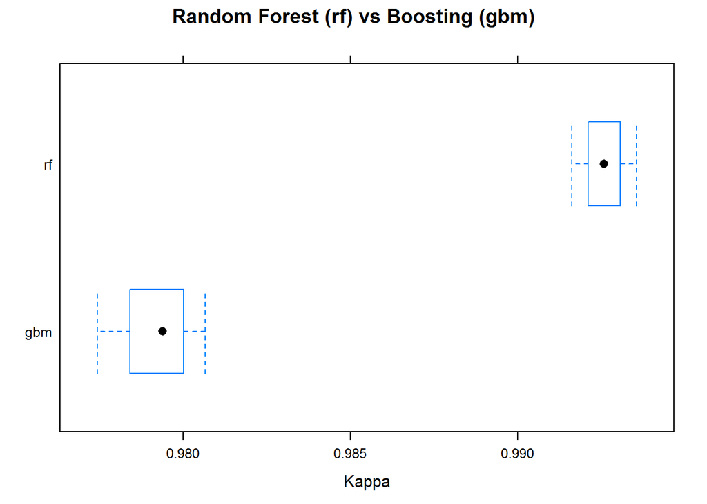

```r
bwplot(rValues,metric = "Kappa",main = "Random Forest (rf) vs Boosting (gbm)")
```

2. Based on the plot above, the Random Forest model results are better than the Boosting model. Therefore, the Random Forest Model is selected.

### Model Validation

1. Using the selected Random Forest model, we proceed to model validation.
2. The details of the selected model’s output is shown below.

```r
rf_Modfit
```

```
## Random Forest
##
## 11776 samples
##    53 predictor
##     5 classes: 'A', 'B', 'C', 'D', 'E'
##
## No pre-processing
## Resampling: Cross-Validated (3 fold)
## Summary of sample sizes: 7851, 7850, 7851
## Resampling results across tuning parameters:
##
##   mtry  Accuracy   Kappa
##    2    0.9894702  0.9866792
##   27    0.9941406  0.9925885
##   53    0.9892152  0.9863568
##
## Kappa was used to select the optimal model using  the largest value.
## The final value used for the model was mtry = 27.
```

3. Using the confusionMatrix function in the Caret package now validate the selected model with the test_set data set with the corresponding statistics and error rates are shown.

```r
confusionMatrix(test_set$classe, predict(rf_Modfit,test_set))
```

```
## Confusion Matrix and Statistics
##
##           Reference
## Prediction    A    B    C    D    E
##          A 2232    0    0    0    0
##          B    4 1510    3    1    0
##          C    0    3 1365    0    0
##          D    0    0    4 1282    0
##          E    0    0    0    8 1434
##
## Overall Statistics
##
##                Accuracy : 0.9971
##                  95% CI : (0.9956, 0.9981)
##     No Information Rate : 0.285
##     P-Value [Acc > NIR] : < 0.00000000000000022
##
##                   Kappa : 0.9963
##  Mcnemar's Test P-Value : NA
##
## Statistics by Class:
##
##                      Class: A Class: B Class: C Class: D Class: E
## Sensitivity            0.9982   0.9980   0.9949   0.9930   1.0000
## Specificity            1.0000   0.9987   0.9995   0.9994   0.9988
## Pos Pred Value         1.0000   0.9947   0.9978   0.9969   0.9945
## Neg Pred Value         0.9993   0.9995   0.9989   0.9986   1.0000
## Prevalence             0.2850   0.1928   0.1749   0.1645   0.1828
## Detection Rate         0.2845   0.1925   0.1740   0.1634   0.1828
## Detection Prevalence   0.2845   0.1935   0.1744   0.1639   0.1838
## Balanced Accuracy      0.9991   0.9984   0.9972   0.9962   0.9994
```

Final Model Testing

1. Using the selected Random Forest Model now proceed to predict the classification of the testing set.

```r
results <- predict(rf_Modfit,newdata = df_testing)
print(as.data.frame(results))
```

```
##    results
## 1        B
## 2        A
## 3        B
## 4        A
## 5        A
## 6        E
## 7        D
## 8        B
## 9        A
## 10       A
## 11       B
## 12       C
## 13       B
## 14       A
## 15       E
## 16       E
## 17       A
## 18       B
## 19       B
## 20       B
```